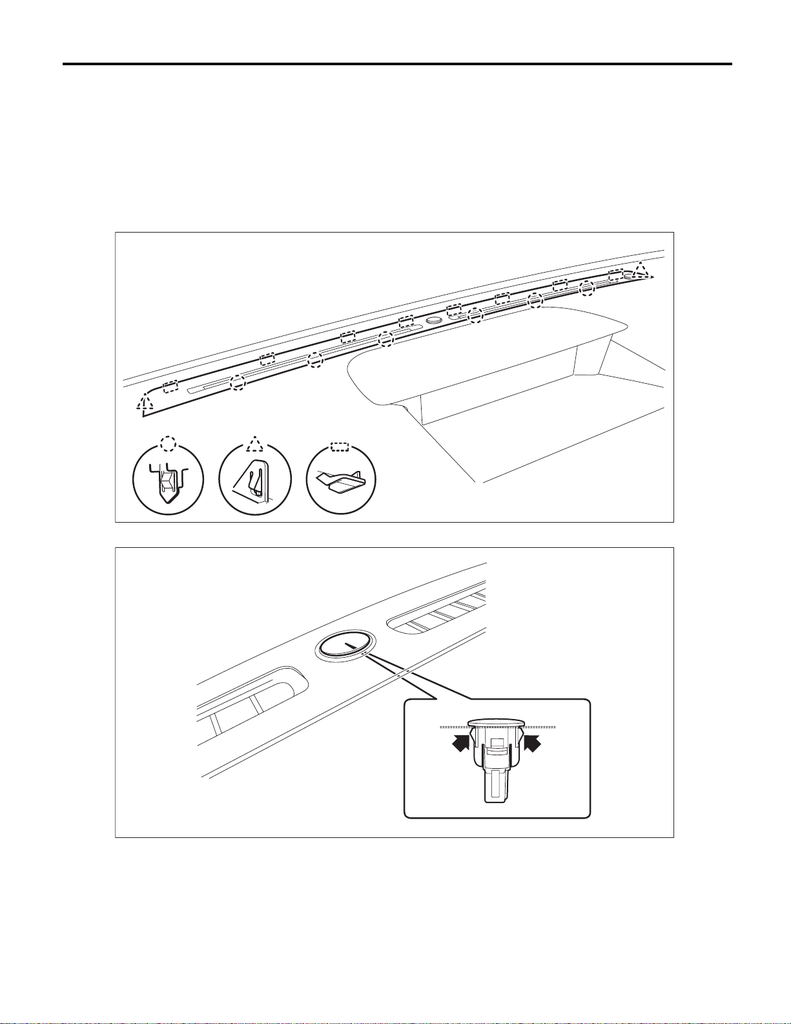

AC-75

Sunload Sensor (Auto A/C Model)

HVAC SYSTEM (HEATER, VENTILATOR AND A/C)

22.Sunload Sensor (Auto A/C Model)

A: REMOVAL

1) Disconnect the ground cable from battery. <Ref. to NT-5, BATTERY, NOTE, Note.>

NOTE:

For models other than STI model, disconnect the ground terminal from battery sensor.

2) Remove the panel COMPL - instrument UPR.

(1) Release the claws.

(2) Disconnect the connectors and remove the panel COMPL - instrument UPR.

3) Release the claws and remove the sensor- sunload.

LI-01185

AC-03545

[figure not shown]

AC-76

Sunload Sensor (Auto A/C Model)

HVAC SYSTEM (HEATER, VENTILATOR AND A/C)

B: INSTALLATION

1) Install the sensor - sunload.

2) Install the panel COMPL - instrument UPR.

3) Connect the battery ground terminal. <Ref. to NT-5, BATTERY, NOTE, Note.>

NOTE:

For models other than STI model, connect the ground terminal to battery sensor.

C: INSPECTION

1) Check if there is anything that affects sensing, around the sensor - sunload.

(1) Is the sensor - sunload free from any other object on it that disturbs sensing?

(2) Is the windshield glass free from any object such as sticker or film that disturbs sensing?

• Yes → Go to step 2).

• No → Remove everything that affects sensing.

2) Using the Subaru Select Monitor, check «Quantity of Sunload».

Preparation tool:

Subaru Select Monitor III kit

NOTE:

For detailed procedures, refer to “PC application help for Subaru Select Monitor”.

(1) Cover the sensor - sunload with cloth.

(2) Does the «Quantity of Sunload» indicate 0 W/m

when the direct sunlight is shielded?

• Yes → Go to step 3).

• No → Replace the sensor - sunload.

3) From the condition in step 2), expose the sensor - sunload to light.

(1) Place intense light such as incandescent light at 30 cm or less from the sunload sensor.

(2) Does «Quantity of Sunload» indicate 2,000 W/m

or less?

CAUTION:

The value changes depending on the angle of light.

• Yes → The sensor - sunload is normal.

• No → Replace the sensor - sunload.